# Reproducible Research : Project 2

# Effect of weather events on personal as well as property damages on Population Health and Economy

## Loading and Processing the Data

Data (https://d396qusza40orc.cloudfront.net/repdata%2Fdata%2FStormData.csv.bz2) are avaible on-line as well as documentaion (https://d396qusza40orc.cloudfront.net/repdata%2Fpeer2_doc%2Fpd01016005curr.pdf) and FAQ (https://d396qusza40orc.cloudfront.net/repdata%2Fpeer2_doc%2FNCDC%20Storm%20Events-FAQ%20Page.pdf). The events in the database start in the year 1950 and end in November 2011. In the earlier years of the database there are generally fewer events recorded, most likely due to a lack of good records. More recent years should be considered more complete.

```r
url <- "https://d396qusza40orc.cloudfront.net/repdata%2Fdata%2FStormData.csv.bz2"
download.file (url, destfile = "StormData.csv.bz2", method="curl", quiet=TRUE)

library(R.utils)
bunzip2 ("StormData.csv.bz2", overwrite=TRUE, remove=FALSE, destname="StormData.csv")

StormData<- read.csv ("StormData.csv", header=TRUE, stringsAsFactors=FALSE)
```

```r
dim (StormData)
```

```
## [1] 902297     37
```

```r
head (StormData)
```

```
##   STATE__           BGN_DATE BGN_TIME TIME_ZONE COUNTY COUNTYNAME STATE
## 1       1  4/18/1950 0:00:00     0130       CST     97     MOBILE    AL
## 2       1  4/18/1950 0:00:00     0145       CST      3    BALDWIN    AL
## 3       1  2/20/1951 0:00:00     1600       CST     57    FAYETTE    AL
## 4       1   6/8/1951 0:00:00     0900       CST     89    MADISON    AL
## 5       1 11/15/1951 0:00:00     1500       CST     43    CULLMAN    AL
## 6       1 11/15/1951 0:00:00     2000       CST     77 LAUDERDALE    AL
##    EVTYPE BGN_RANGE BGN_AZI BGN_LOCATI END_DATE END_TIME COUNTY_END
## 1 TORNADO         0                                               0
## 2 TORNADO         0                                               0
## 3 TORNADO         0                                               0
## 4 TORNADO         0                                               0
## 5 TORNADO         0                                               0
## 6 TORNADO         0                                               0
##   COUNTYENDN END_RANGE END_AZI END_LOCATI LENGTH WIDTH F MAG FATALITIES
```

[output cut: 20 more lines]

## Processing

We will consider here only part of the information from original table, namely State, type of event, number of fatalities and injuries, estimate about damages.

```r
Event<- c("STATE", "EVTYPE", "FATALITIES", "INJURIES", "PROPDMG", "PROPDMGEXP","CROPDMG", "CROPDMGEXP")
data <- StormData[Event]
```

```r
head (Event)
```

```
## [1] "STATE"      "EVTYPE"     "FATALITIES" "INJURIES"   "PROPDMG"
## [6] "PROPDMGEXP"
```

```r
unique(data$PROPDMGEXP)
```

```
##  [1] "K" "M" ""  "B" "m" "+" "0" "5" "6" "?" "4" "2" "3" "h" "7" "H" "-"
## [18] "1" "8"
```

```r
unique(data$CROPDMGEXP)
```

```
## [1] ""  "M" "K" "m" "B" "?" "0" "k" "2"
```

```r
# Assigning values for the property exponent data
data$PROPEXP[data$PROPDMGEXP == "K"] <- 1000
data$PROPEXP[data$PROPDMGEXP == "M"] <- 1e+06
data$PROPEXP[data$PROPDMGEXP == ""] <- 1
data$PROPEXP[data$PROPDMGEXP == "B"] <- 1e+09
data$PROPEXP[data$PROPDMGEXP == "m"] <- 1e+06
data$PROPEXP[data$PROPDMGEXP == "0"] <- 1
data$PROPEXP[data$PROPDMGEXP == "5"] <- 1e+05
data$PROPEXP[data$PROPDMGEXP == "6"] <- 1e+06
data$PROPEXP[data$PROPDMGEXP == "4"] <- 10000
data$PROPEXP[data$PROPDMGEXP == "2"] <- 100
data$PROPEXP[data$PROPDMGEXP == "3"] <- 1000
data$PROPEXP[data$PROPDMGEXP == "h"] <- 100
data$PROPEXP[data$PROPDMGEXP == "7"] <- 1e+07
data$PROPEXP[data$PROPDMGEXP == "H"] <- 100
data$PROPEXP[data$PROPDMGEXP == "1"] <- 10
data$PROPEXP[data$PROPDMGEXP == "8"] <- 1e+08
# Assigning '0' to invalid exponent data
data$PROPEXP[data$PROPDMGEXP == "+"] <- 0
data$PROPEXP[data$PROPDMGEXP == "-"] <- 0
data$PROPEXP[data$PROPDMGEXP == "?"] <- 0
# Calculating the property damage value
data$PROPDMGVAL <- data$PROPDMG * data$PROPEXP
```

```r
data$CROPEXP[data$CROPDMGEXP == "M"] <- 1e+06
data$CROPEXP[data$CROPDMGEXP == "K"] <- 1000
data$CROPEXP[data$CROPDMGEXP == "m"] <- 1e+06
data$CROPEXP[data$CROPDMGEXP == "B"] <- 1e+09
data$CROPEXP[data$CROPDMGEXP == "0"] <- 1
data$CROPEXP[data$CROPDMGEXP == "k"] <- 1000
data$CROPEXP[data$CROPDMGEXP == "2"] <- 100
data$CROPEXP[data$CROPDMGEXP == ""] <- 1
# Assigning '0' to invalid exponent data
data$CROPEXP[data$CROPDMGEXP == "?"] <- 0
# calculating the crop damage value
data$CROPDMGVAL <- data$CROPDMG * data$CROPEXP
```

# Results

## Fatalities

We investigate here the type of event that caused the largest total number of fatalities from 1950 to November 2011:

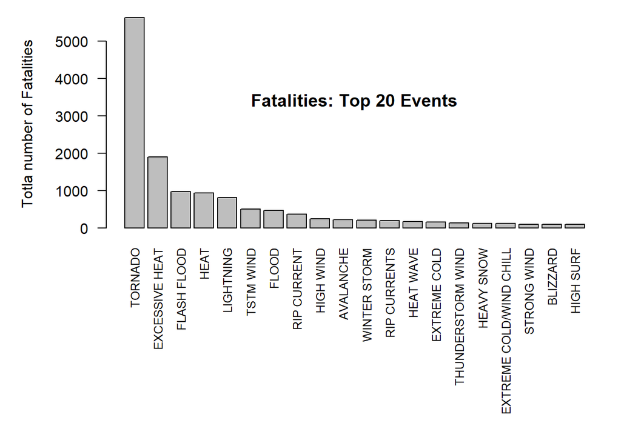

```r
fatal <- aggregate (FATALITIES~EVTYPE, data, FUN = sum)
fatal <- fatal [order(fatal$FATALITIES, decreasing=TRUE),]
par(mar=c(12, 6, 1, 1))
barplot (height = fatal$FATALITIES[1:20], names.arg = fatal$EVTYPE[1:20], las = 2, cex.names= 0.8,)
title (main = "Fatalities: Top 20 Events", line=-5)
title (ylab = "Totla number of Fatalities", line=4)
```

The histogram shows the total number of fatalities for the 20 top events, order by the total number of fatalities they have caused.

## Injuries

We investigate here the type of event that caused the largest total number of injuries from 1950 to November 2011:

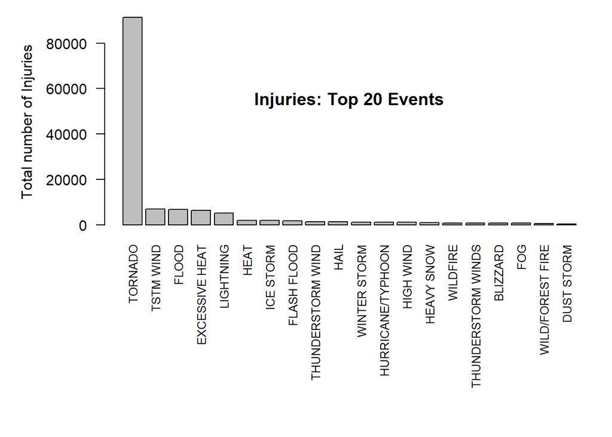

```r
injur <- aggregate (INJURIES~EVTYPE, data, FUN = sum)
injur <- injur [order(injur$INJURIES, decreasing=TRUE),]
par(mar=c(12, 6, 1, 1))
barplot (height = injur$INJURIES[1:20], names.arg = injur$EVTYPE[1:20], las = 2, cex.names = 0.8,)
title (main = "Injuries: Top 20 Events", line=-5)
title (ylab = "Total number of Injuries", line=4)
```

The histogram shows the total number of injuries for the 20 top events, order by the total number of injuries they have caused.

## Economic Damages

We investigate here the total economic damage produced by each type of event, to evaluate those that caused the largest costs. Property and crop damages are summed-up over the years from 1950.

```r
propdmg <- aggregate(PROPDMGVAL ~ EVTYPE, data, sum)
cropdmg <- aggregate(CROPDMGVAL ~ EVTYPE, data, sum)
```

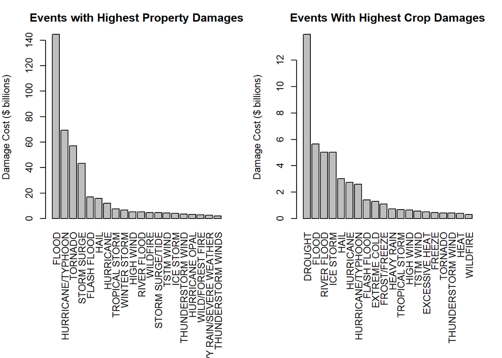

```r
#Finding events with highest property damage
propdmg <- propdmg[order(-propdmg$PROPDMGVAL), ][1:20, ]
# Finding events with highest crop damage
cropdmg <- cropdmg[order(-cropdmg$CROPDMGVAL), ][1:20, ]
par(mfrow = c(1, 2), mar = c(12, 4, 3, 2), mgp = c(3, 1, 0), cex = 0.8)
barplot(propdmg$PROPDMGVAL/(10^9), las = 3, names.arg = propdmg$EVTYPE,
        main = "Events with Highest Property Damages", ylab = "Damage Cost ($ billions)")
barplot(cropdmg$CROPDMGVAL/(10^9), las = 3, names.arg = cropdmg$EVTYPE,
        main = "Events With Highest Crop Damages", ylab = "Damage Cost ($ billions)")
```

Flood is the event that has caused the largest economic damage, as shown in the above histogram of the economic damage caused by the top 20 events.

# Conclusion

It is evident from the exploratory analysis presented here that flood is the event linked to the largest economic damage. Tornado is the event that has most affected human health, both in terms of fatalities and injuries, over the years from 1950 to 2011. If agriculture is the main concern, then drought may be the most concerning factor for economy. But for the economy in general, flood becomes the main loss factor. Concerning human health, more priorities naturally will go towards addressing tornado as it claims most lives and causes injuries.